## University of Texas at Dallas

## EPPS 6323: Knowledge Mining

### Academic Analytics: Predictions around Argentine “Aprender” National Evaluation

### Student: Federico Ferrero

### Clear your memory

```r
rm(list=ls())
```

### Reading in the data

```r
mydata <- read.delim("/Users/feder/Desktop/km_project/aprender_cordoba_dataset.txt")
```

### Names of variables

```r
names(mydata)
```

```
##   [1] "ID1"                            "cod_provincia"
##   [3] "sector"                         "ambito"
##   [5] "claveseccion"                   "idalumno"
##   [7] "ap01_01"                        "ap01_02"
##   [9] "ap02"                           "gender"
##  [11] "female"                         "ap03"
##  [13] "ap04"                           "ap05"
##  [15] "ap06"                           "ap07"
##  [17] "ap08_a"                         "ap08_b"
##  [19] "ap08_c"                         "ap08_d"
##  [21] "ap08_e"                         "ap08_f"
##  [23] "ap08_g"                         "ap08_h"
##  [25] "ap08_i"                         "ap09"
##  [27] "ap10"                           "ap11_01"
##  [29] "ap11_02"                        "ap11_03"
```

[output cut: 118 more lines]

## Exploratory Data Analysis

### Language Performance ~ Math Performance

```r
library("car")
```

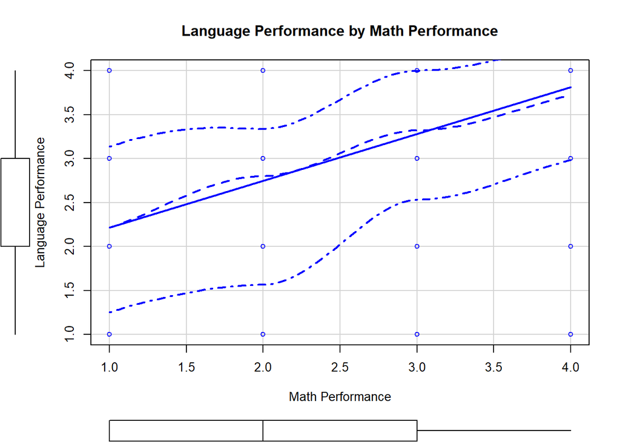

```r
scatterplot(ldesemp ~ mdesemp, data=mydata,
            xlab="Math Performance", ylab="Language Performance",
            main="Language Performance by Math Performance")
```

### Students’ performances by Sector and Ambit

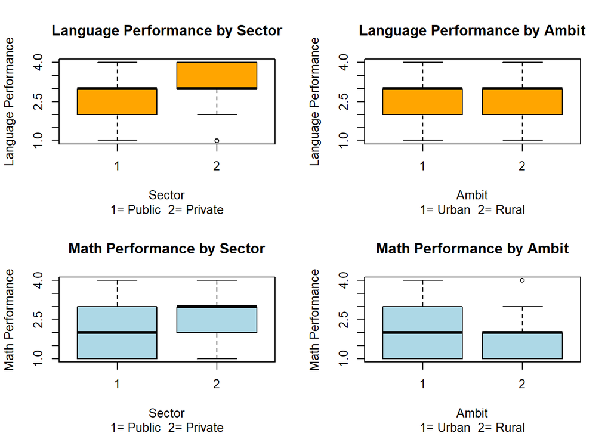

```r
par(mfrow=c(2, 2))
boxplot(ldesemp~sector,data=mydata, main="Language Performance by Sector", sub="1= Public  2= Private",
        xlab="Sector", ylab="Language Performance", col="orange")

boxplot(ldesemp~ambito,data=mydata, main="Language Performance by Ambit", sub="1= Urban  2= Rural",
        xlab="Ambit", ylab="Language Performance", col="orange")

boxplot(mdesemp~sector,data=mydata, main="Math Performance by Sector", sub="1= Public  2= Private",
        xlab="Sector", ylab="Math Performance", col="lightblue")

boxplot(mdesemp~ambito,data=mydata, main="Math Performance by Ambit", sub="1= Urban  2= Rural",
        xlab="Ambit", ylab="Math Performance", col="lightblue")
```

### Students’ performances by Gender

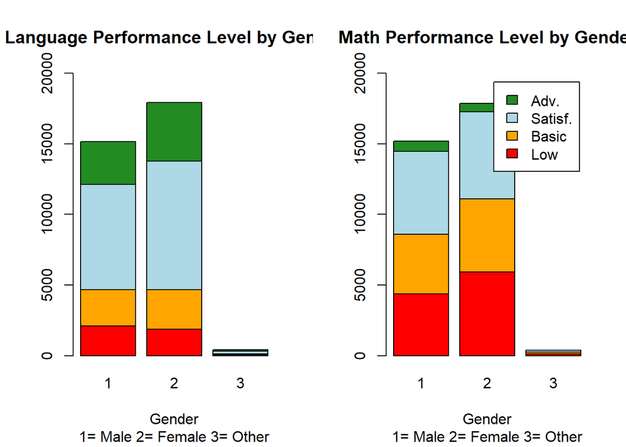

```r
par(mfrow=c(1, 2))

counts1 <- table(mydata$ldesemp, mydata$gender)
barplot(counts1, main="Language Performance Level by Gender", sub="1= Male 2= Female 3= Other",
        xlab="Gender", col=c("red","orange","lightblue","forestgreen"), ylim=c(0,20000))


counts2 <- table(mydata$mdesemp, mydata$gender)
barplot(counts2, main="Math Performance Level by Gender", sub="1= Male 2= Female 3= Other",
        xlab="Gender", col=c("red","orange","lightblue","forestgreen"),
        legend.text = c("Low", "Basic", "Satisf.", "Adv."), ylim=c(0,20000))
```

### Students’ performances by Repetition and Work Experience

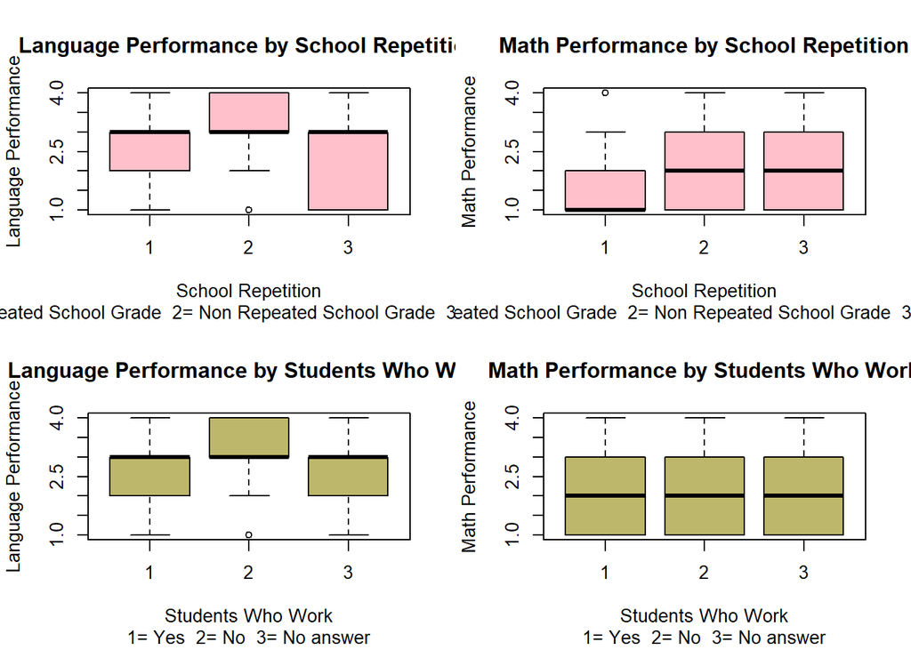

```r
par(mfrow=c(2, 2))
boxplot(ldesemp~repitencia_dicotomica,data=mydata, main="Language Performance by School Repetition", sub="1= Repeated School Grade  2= Non Repeated School Grade  3= No answer",
        xlab="School Repetition", ylab="Language Performance", col="pink")

boxplot(mdesemp~repitencia_dicotomica,data=mydata, main="Math Performance by School Repetition", sub="1= Repeated School Grade  2= Non Repeated School Grade  3= No answer",
        xlab="School Repetition", ylab="Math Performance", col="pink")

boxplot(ldesemp~trabaja_fuera_hogar,data=mydata, main="Language Performance by Students Who Work", sub="1= Yes  2= No  3= No answer",
        xlab="Students Who Work", ylab="Language Performance", col="darkkhaki")

boxplot(mdesemp~trabaja_fuera_hogar,data=mydata, main="Math Performance by Students Who Work", sub="1= Yes  2= No  3= No answer",
        xlab="Students Who Work", ylab="Math Performance", col="darkkhaki")
```

### Students’ Performances by Socioeconomic Level

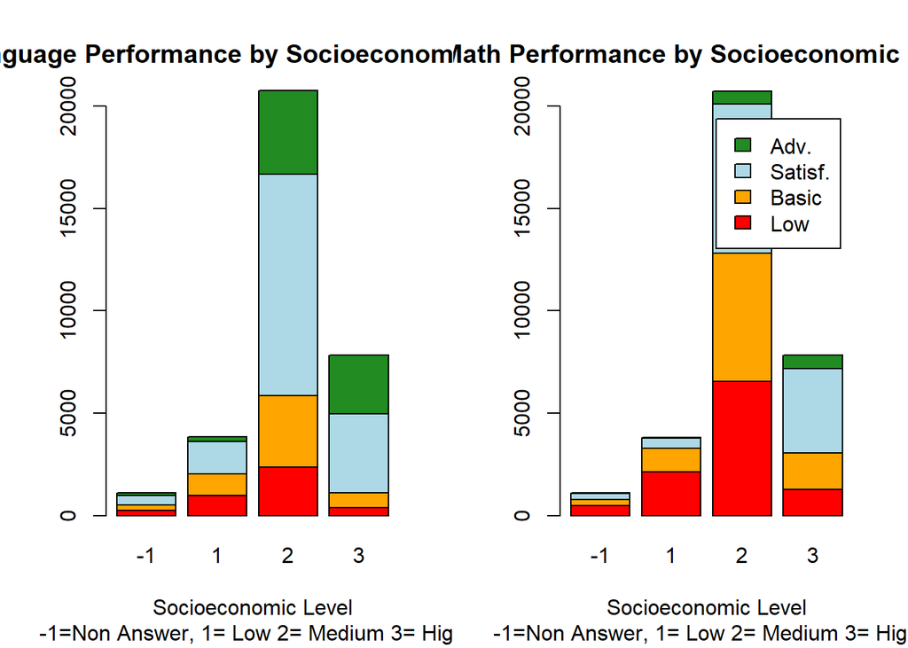

```r
par(mfrow=c(1, 2))

counts1 <- table(mydata$ldesemp, mydata$isocioa)
barplot(counts1, main="Language Performance by Socioeconomic Level", sub="-1=Non Answer, 1= Low 2= Medium 3= High",
        xlab="Socioeconomic Level", col=c("red","orange","lightblue","forestgreen"), ylim=c(0,20000))


counts2 <- table(mydata$mdesemp, mydata$isocioa)
barplot(counts2, main="Math Performance by Socioeconomic Level", sub="-1=Non Answer, 1= Low 2= Medium 3= High",
        xlab="Socioeconomic Level", col=c("red","orange","lightblue","forestgreen"),
        legend.text = c("Low", "Basic", "Satisf.", "Adv."), ylim=c(0,20000))
```

## Finding the best models for Argentine Aprender Evaluation

### Reading in the data

```r
mydata <- read.delim("/Users/feder/Desktop/km_project/aprender_cordoba_dataset_to_subset.txt")
```

### Save the 1 best model per subset size for language and math performance

```r
library(leaps)
leaps1<- regsubsets(ldesemp ~., data= mydata, nbest=1, method = "backward")
summary(leaps1)
```

```
## Subset selection object
## Call: regsubsets.formula(ldesemp ~ ., data = mydata, nbest = 1, method = "backward")
## 247 Variables  (and intercept)
##                                Forced in Forced out
## mdesemp                            FALSE      FALSE
## sector                             FALSE      FALSE
## ambito                             FALSE      FALSE
## ap01_01                            FALSE      FALSE
## ap01_02                            FALSE      FALSE
## gender                             FALSE      FALSE
## ap03                               FALSE      FALSE
## ap04                               FALSE      FALSE
## ap05                               FALSE      FALSE
## ap06                               FALSE      FALSE
## ap07                               FALSE      FALSE
## ap08_a                             FALSE      FALSE
## ap08_b                             FALSE      FALSE
## ap08_c                             FALSE      FALSE
## ap08_d                             FALSE      FALSE
## ap08_e                             FALSE      FALSE
## ap08_f                             FALSE      FALSE
## ap08_g                             FALSE      FALSE
## ap08_h                             FALSE      FALSE
## ap08_i                             FALSE      FALSE
## ap09                               FALSE      FALSE
## ap10                               FALSE      FALSE
## ap11_01                            FALSE      FALSE
## ap11_02                            FALSE      FALSE
## ap11_03                            FALSE      FALSE
## ap11_04                            FALSE      FALSE
## ap11_05                            FALSE      FALSE
## ap11_06                            FALSE      FALSE
## ap11_07                            FALSE      FALSE
## ap11_08                            FALSE      FALSE
## ap12                               FALSE      FALSE
## ap13                               FALSE      FALSE
## ap14_01                            FALSE      FALSE
## ap14_02                            FALSE      FALSE
## ap15                               FALSE      FALSE
## ap16                               FALSE      FALSE
```

[output cut: 468 more lines]

```
## 3  ( 1 ) " "                            " "       " "             " "
## 4  ( 1 ) " "                            " "       " "             " "
## 5  ( 1 ) " "                            " "       " "             "*"
## 6  ( 1 ) " "                            " "       "*"             "*"
## 7  ( 1 ) " "                            " "       "*"             "*"
## 8  ( 1 ) " "                            " "       "*"             "*"
##          iinfraestructura ap42_01rec ap42_02rec ap42_03rec ap42_04rec
## 1  ( 1 ) " "              " "        " "        " "        " "
## 2  ( 1 ) " "              " "        " "        " "        " "
## 3  ( 1 ) " "              " "        " "        " "        " "
## 4  ( 1 ) " "              " "        " "        " "        " "
## 5  ( 1 ) " "              " "        " "        " "        " "
## 6  ( 1 ) " "              " "        " "        " "        " "
## 7  ( 1 ) " "              " "        " "        " "        " "
## 8  ( 1 ) " "              " "        " "        " "        " "
```

```r
leaps2<- regsubsets(mdesemp ~., data= mydata, nbest=1, method = "forward")
summary(leaps2)
```

```
## Subset selection object
## Call: regsubsets.formula(mdesemp ~ ., data = mydata, nbest = 1, method = "forward")
## 247 Variables  (and intercept)
##                                Forced in Forced out
## ldesemp                            FALSE      FALSE
## sector                             FALSE      FALSE
## ambito                             FALSE      FALSE
## ap01_01                            FALSE      FALSE
## ap01_02                            FALSE      FALSE
## gender                             FALSE      FALSE
## ap03                               FALSE      FALSE
## ap04                               FALSE      FALSE
## ap05                               FALSE      FALSE
## ap06                               FALSE      FALSE
## ap07                               FALSE      FALSE
## ap08_a                             FALSE      FALSE
## ap08_b                             FALSE      FALSE
## ap08_c                             FALSE      FALSE
## ap08_d                             FALSE      FALSE
## ap08_e                             FALSE      FALSE
## ap08_f                             FALSE      FALSE
## ap08_g                             FALSE      FALSE
## ap08_h                             FALSE      FALSE
## ap08_i                             FALSE      FALSE
## ap09                               FALSE      FALSE
## ap10                               FALSE      FALSE
## ap11_01                            FALSE      FALSE
## ap11_02                            FALSE      FALSE
## ap11_03                            FALSE      FALSE
## ap11_04                            FALSE      FALSE
## ap11_05                            FALSE      FALSE
## ap11_06                            FALSE      FALSE
## ap11_07                            FALSE      FALSE
## ap11_08                            FALSE      FALSE
## ap12                               FALSE      FALSE
## ap13                               FALSE      FALSE
## ap14_01                            FALSE      FALSE
## ap14_02                            FALSE      FALSE
## ap15                               FALSE      FALSE
## ap16                               FALSE      FALSE
```

[output cut: 468 more lines]

```
## 3  ( 1 ) " "                            " "       " "             " "
## 4  ( 1 ) " "                            " "       " "             " "
## 5  ( 1 ) " "                            " "       " "             " "
## 6  ( 1 ) " "                            " "       " "             " "
## 7  ( 1 ) " "                            " "       " "             " "
## 8  ( 1 ) " "                            " "       " "             " "
##          iinfraestructura ap42_01rec ap42_02rec ap42_03rec ap42_04rec
## 1  ( 1 ) " "              " "        " "        " "        " "
## 2  ( 1 ) " "              " "        " "        " "        " "
## 3  ( 1 ) " "              " "        " "        " "        " "
## 4  ( 1 ) " "              " "        " "        " "        " "
## 5  ( 1 ) " "              " "        " "        " "        " "
## 6  ( 1 ) " "              " "        " "        " "        " "
## 7  ( 1 ) " "              " "        " "        " "        " "
## 8  ( 1 ) " "              " "        " "        " "        " "
```

### How many predictors are the optimal number when predicting language performance?

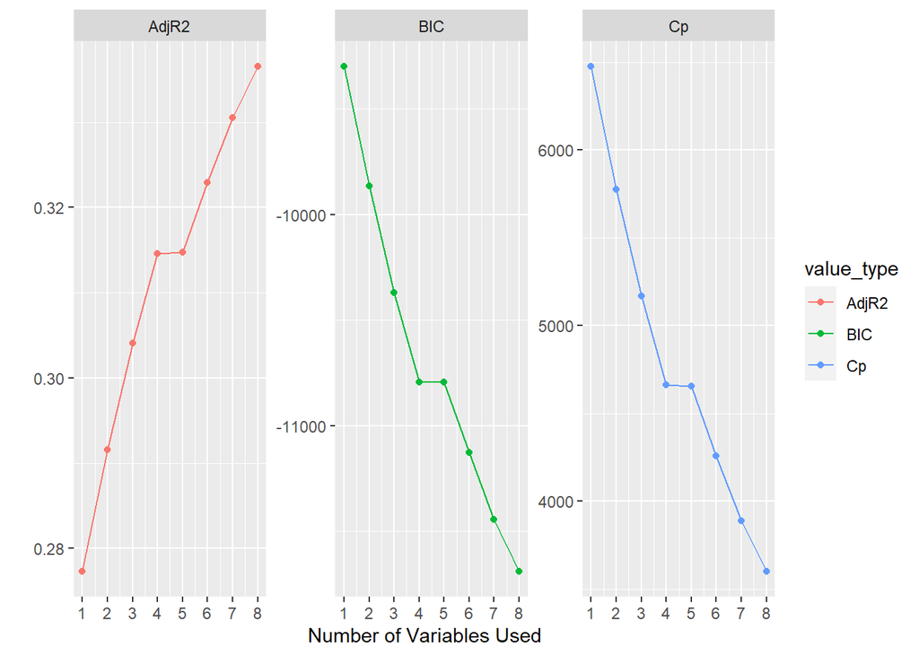

```r
leaps_summary1 <- summary(leaps1)
require(tidyverse);require(ggplot2);require(ggthemes);
data_frame(Cp = leaps_summary1$cp,
           BIC = leaps_summary1$bic,
           AdjR2 = leaps_summary1$adjr2) %>%
        mutate(id = row_number()) %>%
        gather(value_type, value, -id) %>%
        ggplot(aes(id, value, col = value_type)) +
        geom_line() + geom_point() + ylab('') + xlab('Number of Variables Used') +
        facet_wrap(~ value_type, scales = 'free') + scale_x_continuous(breaks = 1:10)
```

### Now, plot statistics by subset size (bic, cp, adjr2) when predicting language performance

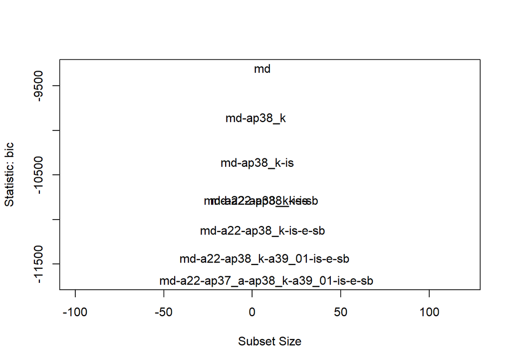

```
##                                Abbreviation
## mdesemp                                  md
## sector                                   sc
## ambito                                   am
## ap01_01                              a01_01
## ap01_02                              a01_02
## gender                                    g
## ap03                                    a03
## ap04                                    a04
## ap05                                    a05
## ap06                                    a06
## ap07                                    a07
## ap08_a                               ap08_a
## ap08_b                               ap08_b
## ap08_c                               ap08_c
## ap08_d                               ap08_d
## ap08_e                               ap08_e
## ap08_f                               ap08_f
## ap08_g                               ap08_g
## ap08_h                               ap08_h
## ap08_i                               ap08_i
## ap09                                    a09
## ap10                                    a10
## ap11_01                              a11_01
## ap11_02                              a11_02
## ap11_03                              a11_03
## ap11_04                              a11_04
## ap11_05                              a11_05
## ap11_06                              a11_06
## ap11_07                              a11_07
## ap11_08                              a11_08
## ap12                                    a12
## ap13                                    a13
## ap14_01                              a14_01
## ap14_02                              a14_02
## ap15                                    a15
## ap16                                    a16
## ap17                                    a17
## ap18_01                              a18_01
## ap18_02                              a18_02
```

[output cut: 193 more lines]

```
## ap29_04.dico                        a29_04.
## ap29_05.dico                        a29_05.
## ap29_06.dico                        a29_06.
## ap29_07.dico                        a29_07.
## ap26_rec                               a26_
## trabaja_fuera_hogar                    tr__
## trabaja_fuera_hogar_remunerado         t___
## migración                                mg
## edadA_junio2019                           e
## sobreedad                                sb
## iinfraestructura                         in
## ap42_01rec                         ap42_01r
## ap42_02rec                         ap42_02r
## ap42_03rec                         ap42_03r
## ap42_04rec                         ap42_04r
```

```r
library(car)

subsets(leaps1, statistic="bic", xlim=c(-100,120), legend = FALSE)
```

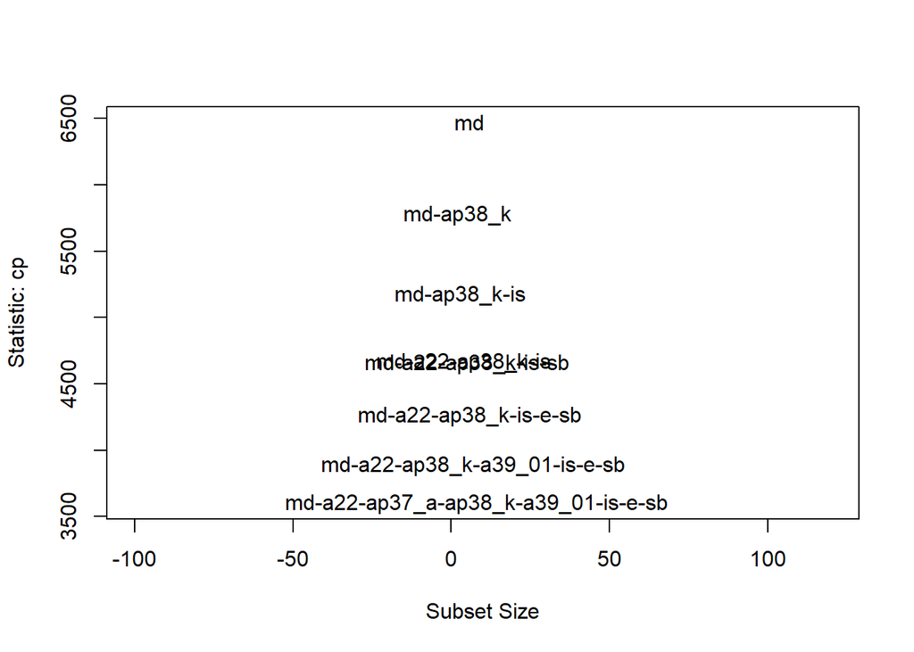

```
##                                Abbreviation
## mdesemp                                  md
## sector                                   sc
## ambito                                   am
## ap01_01                              a01_01
## ap01_02                              a01_02
## gender                                    g
## ap03                                    a03
## ap04                                    a04
## ap05                                    a05
## ap06                                    a06
## ap07                                    a07
## ap08_a                               ap08_a
## ap08_b                               ap08_b
## ap08_c                               ap08_c
## ap08_d                               ap08_d
## ap08_e                               ap08_e
## ap08_f                               ap08_f
## ap08_g                               ap08_g
## ap08_h                               ap08_h
## ap08_i                               ap08_i
## ap09                                    a09
## ap10                                    a10
## ap11_01                              a11_01
## ap11_02                              a11_02
## ap11_03                              a11_03
## ap11_04                              a11_04
## ap11_05                              a11_05
## ap11_06                              a11_06
## ap11_07                              a11_07
## ap11_08                              a11_08
## ap12                                    a12
## ap13                                    a13
## ap14_01                              a14_01
## ap14_02                              a14_02
## ap15                                    a15
## ap16                                    a16
## ap17                                    a17
## ap18_01                              a18_01
## ap18_02                              a18_02
```

[output cut: 193 more lines]

```
## ap29_04.dico                        a29_04.
## ap29_05.dico                        a29_05.
## ap29_06.dico                        a29_06.
## ap29_07.dico                        a29_07.
## ap26_rec                               a26_
## trabaja_fuera_hogar                    tr__
## trabaja_fuera_hogar_remunerado         t___
## migración                                mg
## edadA_junio2019                           e
## sobreedad                                sb
## iinfraestructura                         in
## ap42_01rec                         ap42_01r
## ap42_02rec                         ap42_02r
## ap42_03rec                         ap42_03r
## ap42_04rec                         ap42_04r
```

```r
subsets(leaps1, statistic="cp", xlim=c(-100,120), legend = FALSE)
```

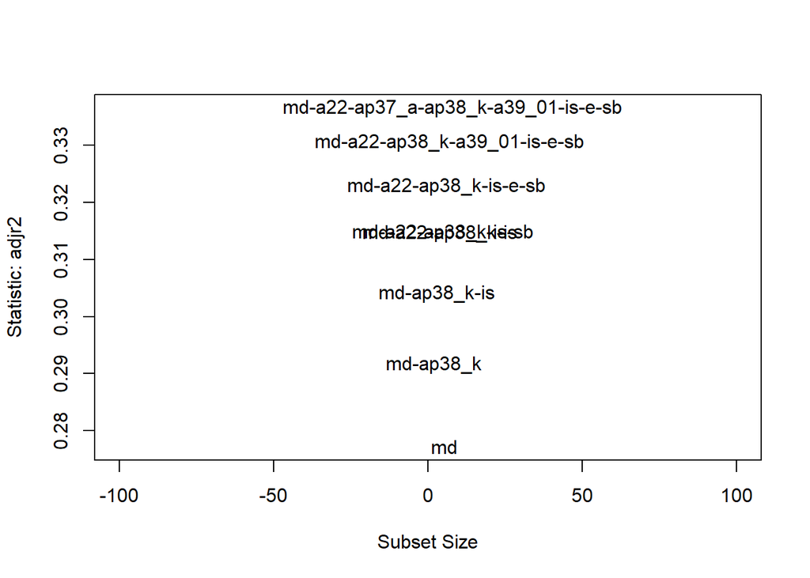

```
##                                Abbreviation
## mdesemp                                  md
## sector                                   sc
## ambito                                   am
## ap01_01                              a01_01
## ap01_02                              a01_02
## gender                                    g
## ap03                                    a03
## ap04                                    a04
## ap05                                    a05
## ap06                                    a06
## ap07                                    a07
## ap08_a                               ap08_a
## ap08_b                               ap08_b
## ap08_c                               ap08_c
## ap08_d                               ap08_d
## ap08_e                               ap08_e
## ap08_f                               ap08_f
## ap08_g                               ap08_g
## ap08_h                               ap08_h
## ap08_i                               ap08_i
## ap09                                    a09
## ap10                                    a10
## ap11_01                              a11_01
## ap11_02                              a11_02
## ap11_03                              a11_03
## ap11_04                              a11_04
## ap11_05                              a11_05
## ap11_06                              a11_06
## ap11_07                              a11_07
## ap11_08                              a11_08
## ap12                                    a12
## ap13                                    a13
## ap14_01                              a14_01
## ap14_02                              a14_02
## ap15                                    a15
## ap16                                    a16
## ap17                                    a17
## ap18_01                              a18_01
## ap18_02                              a18_02
```

[output cut: 193 more lines]

```
## ap29_04.dico                        a29_04.
## ap29_05.dico                        a29_05.
## ap29_06.dico                        a29_06.
## ap29_07.dico                        a29_07.
## ap26_rec                               a26_
## trabaja_fuera_hogar                    tr__
## trabaja_fuera_hogar_remunerado         t___
## migración                                mg
## edadA_junio2019                           e
## sobreedad                                sb
## iinfraestructura                         in
## ap42_01rec                         ap42_01r
## ap42_02rec                         ap42_02r
## ap42_03rec                         ap42_03r
## ap42_04rec                         ap42_04r
```

```r
subsets(leaps1, statistic="adjr2", xlim=c(-100,100), legend=FALSE)
```

### How many predictors are the optimal number when predicting math performance?

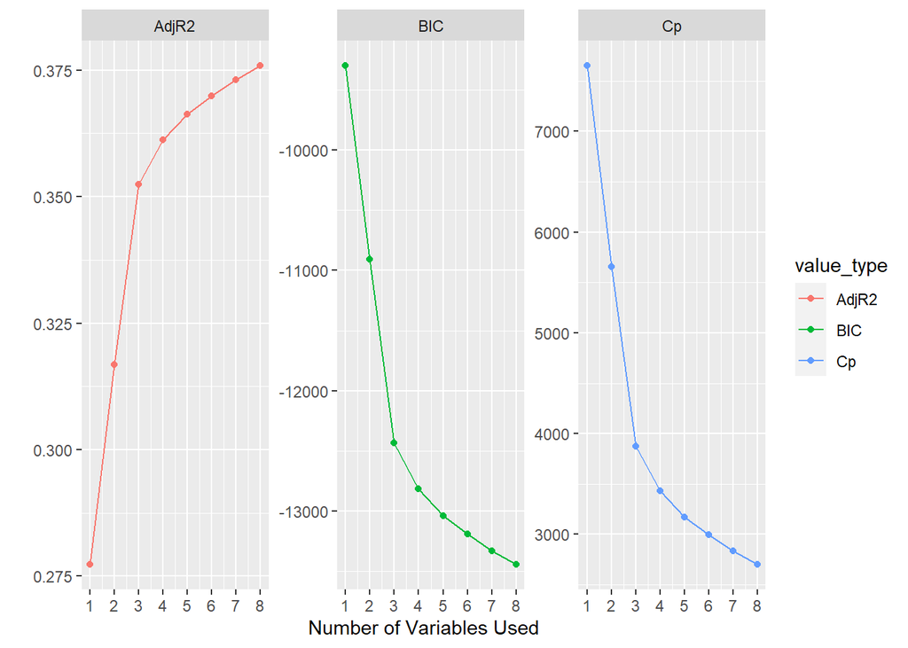

```r
leaps_summary2 <- summary(leaps2)

data_frame(Cp = leaps_summary2$cp,
           BIC = leaps_summary2$bic,
           AdjR2 = leaps_summary2$adjr2) %>%
        mutate(id = row_number()) %>%
        gather(value_type, value, -id) %>%
        ggplot(aes(id, value, col = value_type)) +
        geom_line() + geom_point() + ylab('') + xlab('Number of Variables Used') +
        facet_wrap(~ value_type, scales = 'free') + scale_x_continuous(breaks = 1:10)
```

### 8 seems to be the better number of predictors for the model when predicting math performance: 8 predictors have the highest AdjR2 and the lowest BIC and Cp.

### Plot statistics by subset size (bic, cp, adjr2) when predicting math performance

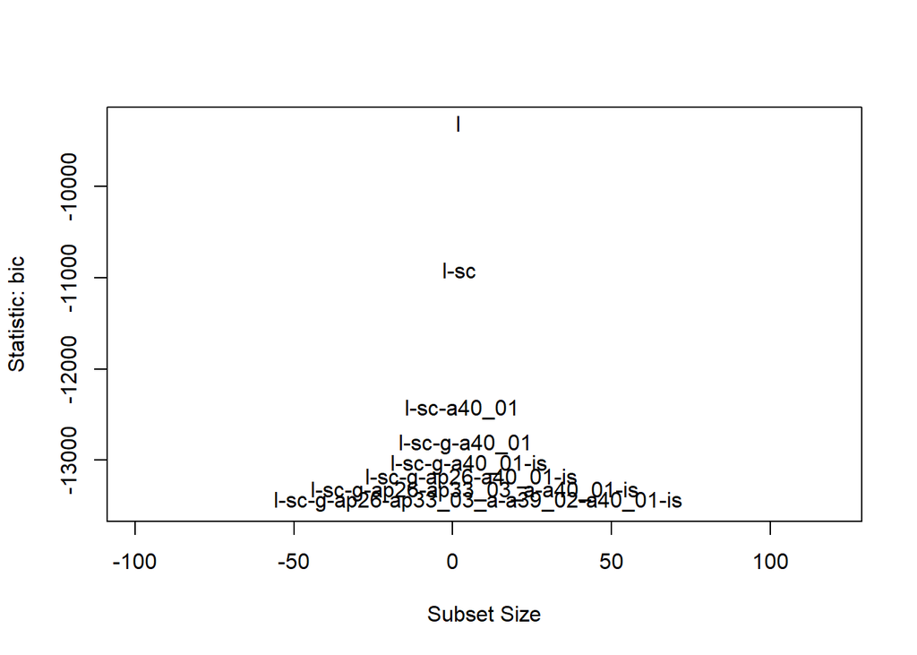

```
##                                Abbreviation
## ldesemp                                   l
## sector                                   sc
## ambito                                   am
## ap01_01                              a01_01
## ap01_02                              a01_02
## gender                                    g
## ap03                                    a03
## ap04                                    a04
## ap05                                    a05
## ap06                                    a06
## ap07                                    a07
## ap08_a                               ap08_a
## ap08_b                               ap08_b
## ap08_c                               ap08_c
## ap08_d                               ap08_d
## ap08_e                               ap08_e
## ap08_f                               ap08_f
## ap08_g                               ap08_g
## ap08_h                               ap08_h
## ap08_i                               ap08_i
## ap09                                    a09
## ap10                                    a10
## ap11_01                              a11_01
## ap11_02                              a11_02
## ap11_03                              a11_03
## ap11_04                              a11_04
## ap11_05                              a11_05
## ap11_06                              a11_06
## ap11_07                              a11_07
## ap11_08                              a11_08
## ap12                                    a12
## ap13                                    a13
## ap14_01                              a14_01
## ap14_02                              a14_02
## ap15                                    a15
## ap16                                    a16
## ap17                                    a17
## ap18_01                              a18_01
## ap18_02                              a18_02
```

[output cut: 193 more lines]

```
## ap29_04.dico                        a29_04.
## ap29_05.dico                        a29_05.
## ap29_06.dico                        a29_06.
## ap29_07.dico                        a29_07.
## ap26_rec                               a26_
## trabaja_fuera_hogar                    tr__
## trabaja_fuera_hogar_remunerado         t___
## migración                                 m
## edadA_junio2019                           e
## sobreedad                                sb
## iinfraestructura                         in
## ap42_01rec                         ap42_01r
## ap42_02rec                         ap42_02r
## ap42_03rec                         ap42_03r
## ap42_04rec                         ap42_04r
```

```r
library(car)
subsets(leaps2, statistic="bic", xlim=c(-100,120), ylim=c(-13500,-9300), legend = FALSE)
```

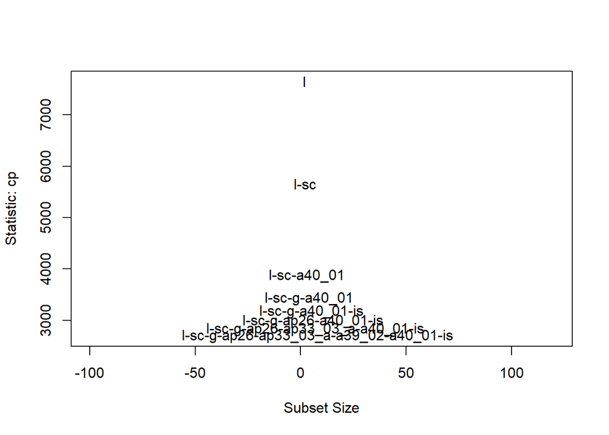

```
##                                Abbreviation
## ldesemp                                   l
## sector                                   sc
## ambito                                   am
## ap01_01                              a01_01
## ap01_02                              a01_02
## gender                                    g
## ap03                                    a03
## ap04                                    a04
## ap05                                    a05
## ap06                                    a06
## ap07                                    a07
## ap08_a                               ap08_a
## ap08_b                               ap08_b
## ap08_c                               ap08_c
## ap08_d                               ap08_d
## ap08_e                               ap08_e
## ap08_f                               ap08_f
## ap08_g                               ap08_g
## ap08_h                               ap08_h
## ap08_i                               ap08_i
## ap09                                    a09
## ap10                                    a10
## ap11_01                              a11_01
## ap11_02                              a11_02
## ap11_03                              a11_03
## ap11_04                              a11_04
## ap11_05                              a11_05
## ap11_06                              a11_06
## ap11_07                              a11_07
## ap11_08                              a11_08
## ap12                                    a12
## ap13                                    a13
## ap14_01                              a14_01
## ap14_02                              a14_02
## ap15                                    a15
## ap16                                    a16
## ap17                                    a17
## ap18_01                              a18_01
## ap18_02                              a18_02
```

[output cut: 193 more lines]

```
## ap29_04.dico                        a29_04.
## ap29_05.dico                        a29_05.
## ap29_06.dico                        a29_06.
## ap29_07.dico                        a29_07.
## ap26_rec                               a26_
## trabaja_fuera_hogar                    tr__
## trabaja_fuera_hogar_remunerado         t___
## migración                                 m
## edadA_junio2019                           e
## sobreedad                                sb
## iinfraestructura                         in
## ap42_01rec                         ap42_01r
## ap42_02rec                         ap42_02r
## ap42_03rec                         ap42_03r
## ap42_04rec                         ap42_04r
```

```r
subsets(leaps2, statistic="cp", xlim=c(-100,120), legend = FALSE)
```

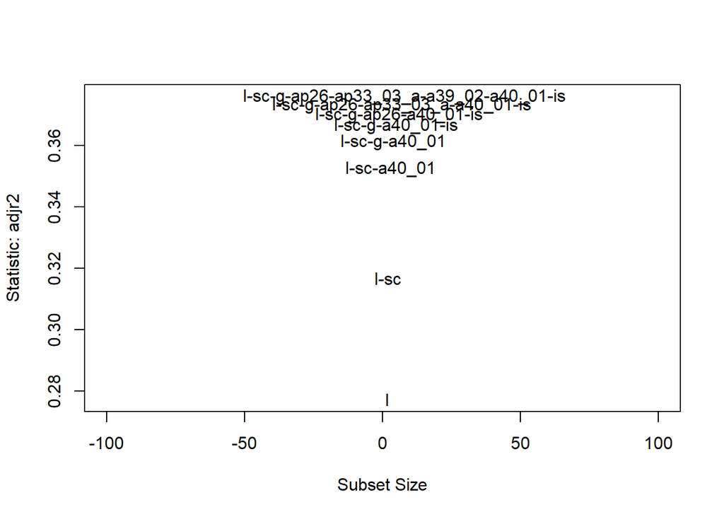

```
##                                Abbreviation
## ldesemp                                   l
## sector                                   sc
## ambito                                   am
## ap01_01                              a01_01
## ap01_02                              a01_02
## gender                                    g
## ap03                                    a03
## ap04                                    a04
## ap05                                    a05
## ap06                                    a06
## ap07                                    a07
## ap08_a                               ap08_a
## ap08_b                               ap08_b
## ap08_c                               ap08_c
## ap08_d                               ap08_d
## ap08_e                               ap08_e
## ap08_f                               ap08_f
## ap08_g                               ap08_g
## ap08_h                               ap08_h
## ap08_i                               ap08_i
## ap09                                    a09
## ap10                                    a10
## ap11_01                              a11_01
## ap11_02                              a11_02
## ap11_03                              a11_03
## ap11_04                              a11_04
## ap11_05                              a11_05
## ap11_06                              a11_06
## ap11_07                              a11_07
## ap11_08                              a11_08
## ap12                                    a12
## ap13                                    a13
## ap14_01                              a14_01
## ap14_02                              a14_02
## ap15                                    a15
## ap16                                    a16
## ap17                                    a17
## ap18_01                              a18_01
## ap18_02                              a18_02
```

[output cut: 193 more lines]

```
## ap29_04.dico                        a29_04.
## ap29_05.dico                        a29_05.
## ap29_06.dico                        a29_06.
## ap29_07.dico                        a29_07.
## ap26_rec                               a26_
## trabaja_fuera_hogar                    tr__
## trabaja_fuera_hogar_remunerado         t___
## migración                                 m
## edadA_junio2019                           e
## sobreedad                                sb
## iinfraestructura                         in
## ap42_01rec                         ap42_01r
## ap42_02rec                         ap42_02r
## ap42_03rec                         ap42_03r
## ap42_04rec                         ap42_04r
```

```r
subsets(leaps2, statistic="adjr2", xlim=c(-100,100), legend=FALSE)
```

### According to the graphs above, and following the codebook, the 7 best predictors for math performance are (one was deleted because it wasn’t conceptually relevant):

- ldesemp= Language performance
- sector= Sector (either public or private)
- gender= Gender
- ap26= Absenteeism. So far this year, how many times have you missed school?
- ap39_02= How difficult do you find the following activities? Writing a text
- ap40_01= To what extent do you agree with the following statements? I enjoy studying Mathematics
- isocia= Student’s socio-economical index

### Run multiple regressions according to the results obtained in subset selection

```r
rightfit_lang=lm(ldesemp~ mdesemp + ap22 + ap39_01 +factor(isocioa) + sobreedad, data=mydata)
summary(rightfit_lang)
```

```
##
## Call:
## lm(formula = ldesemp ~ mdesemp + ap22 + ap39_01 + factor(isocioa) +
##     sobreedad, data = mydata)
##
## Residuals:
##      Min       1Q   Median       3Q      Max
## -2.91814 -0.40730  0.07649  0.62468  2.51955
##
## Coefficients:
##                    Estimate Std. Error t value Pr(>|t|)
## (Intercept)       1.4114056  0.0252469  55.904   <2e-16 ***
## mdesemp           0.4672318  0.0048366  96.603   <2e-16 ***
## ap22             -0.0185926  0.0008372 -22.207   <2e-16 ***
## ap39_01           0.0384708  0.0019996  19.239   <2e-16 ***
## factor(isocioa)1 -0.0282151  0.0263374  -1.071   0.2840
## factor(isocioa)2  0.2190756  0.0239274   9.156   <2e-16 ***
## factor(isocioa)3  0.3601995  0.0250424  14.384   <2e-16 ***
## sobreedad        -0.0051384  0.0021680  -2.370   0.0178 *
## ---
## Signif. codes:  0 '***' 0.001 '**' 0.01 '*' 0.05 '.' 0.1 ' ' 1
##
## Residual standard error: 0.7485 on 33006 degrees of freedom
##   (1177 observations deleted due to missingness)
## Multiple R-squared:  0.3192, Adjusted R-squared:  0.319
## F-statistic:  2210 on 7 and 33006 DF,  p-value: < 2.2e-16
```

```r
rightfit_math=lm(mdesemp~ ldesemp + factor(sector)+ factor(gender) +
                         ap26 + ap39_02 + ap40_01 + factor(isocioa),data=mydata)
summary(rightfit_math)
```

```
##
## Call:
## lm(formula = mdesemp ~ ldesemp + factor(sector) + factor(gender) +
##     ap26 + ap39_02 + ap40_01 + factor(isocioa), data = mydata)
##
## Residuals:
##      Min       1Q   Median       3Q      Max
## -2.25127 -0.50469  0.01578  0.52603  2.61051
##
## Coefficients:
##                   Estimate Std. Error t value Pr(>|t|)
## (Intercept)       0.813066   0.025988  31.286  < 2e-16 ***
## ldesemp           0.439687   0.004720  93.144  < 2e-16 ***
## factor(sector)2   0.312291   0.008758  35.656  < 2e-16 ***
## factor(gender)2  -0.169882   0.008077 -21.032  < 2e-16 ***
## factor(gender)3  -0.134028   0.037599  -3.565 0.000365 ***
## ap26             -0.032972   0.002972 -11.094  < 2e-16 ***
## ap39_02          -0.047744   0.002490 -19.175  < 2e-16 ***
## ap40_01           0.086066   0.002468  34.872  < 2e-16 ***
## factor(isocioa)1 -0.095942   0.025529  -3.758 0.000171 ***
## factor(isocioa)2  0.064344   0.023136   2.781 0.005420 **
## factor(isocioa)3  0.217876   0.024310   8.962  < 2e-16 ***
## ---
## Signif. codes:  0 '***' 0.001 '**' 0.01 '*' 0.05 '.' 0.1 ' ' 1
##
## Residual standard error: 0.7201 on 33003 degrees of freedom
##   (1177 observations deleted due to missingness)
## Multiple R-squared:  0.3683, Adjusted R-squared:  0.3681
## F-statistic:  1924 on 10 and 33003 DF,  p-value: < 2.2e-16
```

## Let’s try other supervised learning techniques: tree-based models

### Decision trees for Language Performance Prediction

```r
library("rpart")
```

```r
library("rpart.plot")
library("rattle")
# AER Package (AER: Applied Econometrics with R)
library(AER)
```

#### Subset data including predictor variables

```r
tree_base <- subset(mydata, select = c(ldesemp, mdesemp, ap22, isocioa, sobreedad))
```

#### Rename variables

```r
names(tree_base)[1] <- "lang_perf"
names(tree_base)[2] <- "math_perf"
names(tree_base)[3] <- "job_pay"
names(tree_base)[4] <- "socioeconom"
names(tree_base)[5] <- "overage"
```

#### Create new dataset without missing data

```r
tree_base <- na.omit(tree_base)
```

#### Recode lang_perf as dummy (1 for satisfactory and advanced, 0 for basic and below). Then set seed.

```r
tree_base$lang_perf <- ifelse(tree_base$lang_perf >= "3", 1, 0);
set.seed(1001)
```

#### Order data by row number

```r
new_tree_base <- tree_base[sample(nrow(tree_base)),]
```

#### Index for training data (selection of 70 % of data)

```r
t_idx <- sample(seq_len(nrow(tree_base)), size = round(0.70 * nrow(tree_base)))
```

#### Build train and test data

```r
traindata <- new_tree_base[t_idx,]
testdata <- new_tree_base[ - t_idx,]
```

#### Decision tree model

```r
dtree_lang <- rpart::rpart(formula = lang_perf ~ ., data = traindata, method = "class", control = rpart.control(cp = 0.001)) # complexity parameter
```

#### Plot Decision tree for language performance

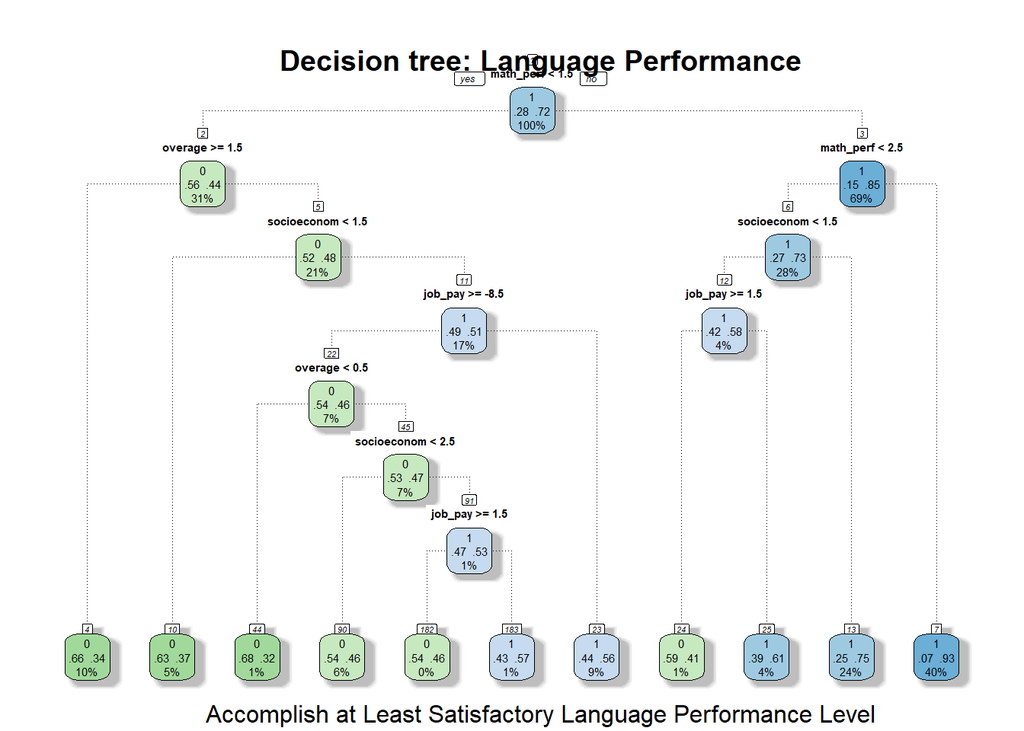

```r
rattle::fancyRpartPlot(dtree_lang, type = 1, main = "Decision tree: Language Performance", caption = "Accomplish at Least Satisfactory Language Performance Level" )
```

```r
resultdt <- predict(dtree_lang, newdata = testdata, type = "class")
```

#### Confusion matrix

```r
cm_langdt <- table(testdata$lang_perf, resultdt, dnn = c("Actual", "Predicted"))
cm_langdt
```

```
##       Predicted
## Actual    0    1
##      0 1288 1491
##      1  807 6318
```

#### Predicted Accomplish rate

```r
cm_langdt[4] / sum(cm_langdt[, 2])
```

```
## [1] 0.8090665
```

#### Predicted Not Accomplish rate

```r
cm_langdt[1] / sum(cm_langdt[, 1])
```

```
## [1] 0.6147971
```

#### Accuracy

```r
accuracydt <- sum(diag(cm_langdt)) / sum(cm_langdt)
accuracydt
```

```
## [1] 0.7679725
```

### Conditional Inference Tree for Language Performance Prediction

```r
# install.packages("party")
library(party)
```

[figure not shown]

```r
cit <- ctree(lang_perf~ ., data = traindata)
plot(cit, main = "Conditional Inference Tree")
```

#### Confusion matrix

```r
cm_langcit = table(testdata$lang_perf, round(predict(cit, newdata = testdata)), dnn = c("Actual", "Predicted"))
cm_langcit
```

```
##       Predicted
## Actual    0    1
##      0 1161 1618
##      1  706 6419
```

#### Predicted Accomplish rate

```r
cm_langcit[4] / sum(cm_langcit[, 2])
```

```
## [1] 0.7986811
```

#### Predicted Not Accomplish rate

```r
cm_langcit[1] / sum(cm_langcit[, 1])
```

```
## [1] 0.6218532
```

#### Accuracy

```r
accuracycit <- sum(diag(cm_langcit)) / sum(cm_langcit)
accuracycit
```

```
## [1] 0.7653473
```

### Decision trees for Math Performance Prediction

#### Subset data including predictor variables

```r
tree_base <- subset(mydata, select = c(mdesemp, ldesemp, sector, gender, ap26,
                                            ap39_02, ap40_01, isocioa))
```

#### Rename variables

```r
names(tree_base)[1] <- "math_perf"
names(tree_base)[2] <- "lang_perf"
names(tree_base)[5] <- "absent"
names(tree_base)[6] <- "dif_writing"
names(tree_base)[7] <- "enjoy_math"
names(tree_base)[8] <- "socioeconom"
```

#### Create new dataset without missing data

```r
tree_base <- na.omit(tree_base)
```

#### Recode math_perf as dummy (1 for satisfactory and advanced, 0 for basic and below). Set seed.

```r
tree_base$math_perf <- ifelse(tree_base$math_perf >= "3", 1, 0);
set.seed(1001)
```

#### Order data by row number

```r
new_tree_base <- tree_base[sample(nrow(tree_base)),]
```

#### Index for training data (selection of 70 % of data)

```r
t_idx <- sample(seq_len(nrow(tree_base)), size = round(0.70 * nrow(tree_base)))
```

#### Build train and test data

```r
traindata <- new_tree_base[t_idx,]
testdata <- new_tree_base[ - t_idx,]
```

#### Decision tree model for math performance prediction

```r
dtree_math <- rpart::rpart(formula = math_perf ~ ., data = traindata, method = "class", control = rpart.control(cp = 0.001)) # complexity parameter
```

#### Plot Decision tree for math performance

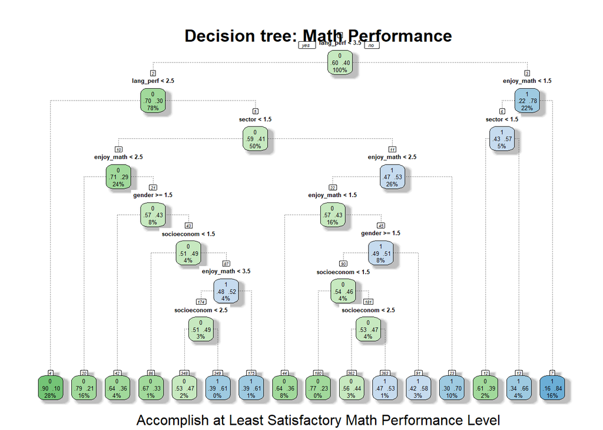

```r
rattle::fancyRpartPlot(dtree_math, type = 1, main = "Decision tree: Math Performance", caption = "Accomplish at Least Satisfactory Math Performance Level" )
```

```r
resultdt <- predict(dtree_math, newdata = testdata, type = "class")
```

#### Confusion matrix

```r
cm_mathdt <- table(testdata$math_perf, resultdt, dnn = c("Actual", "Predicted"))
cm_mathdt
```

```
##       Predicted
## Actual    0    1
##      0 4965  910
##      1 1418 2611
```

#### Predicted Accomplish rate

```r
cm_mathdt[4] / sum(cm_mathdt[, 2])
```

```
## [1] 0.7415507
```

#### Predicted Not Accomplish rate

```r
cm_mathdt[1] / sum(cm_mathdt[, 1])
```

```
## [1] 0.7778474
```

#### Accuracy

```r
accuracydt <- sum(diag(cm_mathdt)) / sum(cm_mathdt)
accuracydt
```

```
## [1] 0.7649435
```

### Conditional Inference Tree for Math Performance Prediction

[figure not shown]

```r
cit <- ctree(math_perf~ ., data = traindata)
plot(cit, main = "Conditional Inference Tree")
```

#### Confusion matrix

```r
cm_mathcit = table(testdata$math_perf, round(predict(cit, newdata = testdata)), dnn = c("Actual", "Predicted"))
cm_mathcit
```

```
##       Predicted
## Actual    0    1
##      0 5053  822
##      1 1545 2484
```

#### Predicted Accomplish rate

```r
cm_mathcit[4] / sum(cm_mathcit[, 2])
```

```
## [1] 0.7513612
```

#### Predicted Not Accomplish rate

```r
cm_mathcit[1] / sum(cm_mathcit[, 1])
```

```
## [1] 0.7658381
```

#### Accuracy

```r
accuracycit <- sum(diag(cm_mathcit)) / sum(cm_mathcit)
accuracycit
```

```
## [1] 0.7610057
```